# HPMT 5335 - Assignment 2

Evan Munro and Jeremy Yeatts

3/4/2021

## **Question 1 (15 points):**

#### **Please refer to “heart” data in package “catdata”. We want to compare the adiposity between heart disease and no heart disease.**

Loading data:

```r
library(catdata)
library(dplyr)
data(heart)
```

### **(1)**

#### **Plot a box plot to show the adiposity between heart disease and no heart disease. Do these two groups have different distributions of adiposity in terms of mean and range? Briefly describe what you find in this box plot.**

```r
heart_df = data.frame(heart)
summary(heart_df)
```

```
##        y               sbp           tobacco             ldl           adiposity        famhist           typea
##  Min.   :0.0000   Min.   :101.0   Min.   : 0.0000   Min.   : 0.980   Min.   : 6.74   Min.   :0.0000   Min.   :13.0
##  1st Qu.:0.0000   1st Qu.:124.0   1st Qu.: 0.0525   1st Qu.: 3.283   1st Qu.:19.77   1st Qu.:0.0000   1st Qu.:47.0
##  Median :0.0000   Median :134.0   Median : 2.0000   Median : 4.340   Median :26.11   Median :0.0000   Median :53.0
##  Mean   :0.3463   Mean   :138.3   Mean   : 3.6356   Mean   : 4.740   Mean   :25.41   Mean   :0.4156   Mean   :53.1
##  3rd Qu.:1.0000   3rd Qu.:148.0   3rd Qu.: 5.5000   3rd Qu.: 5.790   3rd Qu.:31.23   3rd Qu.:1.0000   3rd Qu.:60.0
##  Max.   :1.0000   Max.   :218.0   Max.   :31.2000   Max.   :15.330   Max.   :42.49   Max.   :1.0000   Max.   :78.0
##     obesity         alcohol            age
##  Min.   :14.70   Min.   :  0.00   Min.   :15.00
##  1st Qu.:22.98   1st Qu.:  0.51   1st Qu.:31.00
##  Median :25.80   Median :  7.51   Median :45.00
##  Mean   :26.04   Mean   : 17.04   Mean   :42.82
##  3rd Qu.:28.50   3rd Qu.: 23.89   3rd Qu.:55.00
##  Max.   :46.58   Max.   :147.19   Max.   :64.00
```

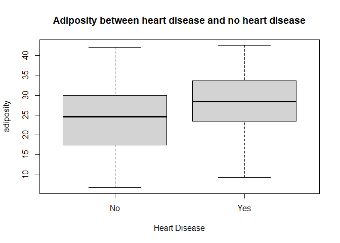

```r
boxplot(data=heart_df,
        adiposity ~ y,
        main="Adiposity between heart disease and no heart disease",
        xlab = "Heart Disease",
        names = c("No", "Yes"))
```

The group with heart disease has a distribution of adiposity scores that shows higher scores at every quartile. The mean adiposity score is higher in the group with heart disease, and the range of adiposity scores is smaller for the heart disease group.

### **(2)**

#### **Do a pooled T-test and see if the means of adiposity between two groups are significantly different. What is the null hypothesis? What is the p-value and what is the 95% confidence interval?**

```r
t.test(x = subset(heart_df$adiposity, heart_df$y==1),
        y = subset(heart_df$adiposity, heart_df$y==0),
        alternative = "two.sided",
        conf.level = 0.95,
        var.equal = T)
```

```
##
##  Two Sample t-test
##
## data:  subset(heart_df$adiposity, heart_df$y == 1) and subset(heart_df$adiposity, heart_df$y == 0)
## t = 5.6353, df = 460, p-value = 3.051e-08
## alternative hypothesis: true difference in means is not equal to 0
## 95 percent confidence interval:
##  2.703560 5.598728
## sample estimates:
## mean of x mean of y
##  28.12025  23.96911
```

Null hypothesis: **$H_0: \mu_0 - \mu_1 = 0$**  
p-value: **3.051e-08**  
95 percent confidence interval: **2.703560 5.598728**

### **(3)**

#### **Do a F test to see if the variances of adiposity between two groups are significantly different if we use $\alpha=0.05$. What is the null hypothesis? What is the p-value and what is the 95% confidence interval?**

```r
var.test(x = subset(heart_df$adiposity, heart_df$y==1),
            y = subset(heart_df$adiposity, heart_df$y==0),
            alternative = "two.sided",
            conf.level = 0.95)
```

```
##
##  F test to compare two variances
##
## data:  subset(heart_df$adiposity, heart_df$y == 1) and subset(heart_df$adiposity, heart_df$y == 0)
## F = 0.82452, num df = 159, denom df = 301, p-value = 0.1734
## alternative hypothesis: true ratio of variances is not equal to 1
## 95 percent confidence interval:
##  0.6314759 1.0891395
## sample estimates:
## ratio of variances
##          0.8245164
```

Null hypothesis: **$H_0: \sigma_1^2 = \sigma_2^2$**  
p-value: **0.1734**  
95 percent confidence interval: **0.6314759 1.0891395**

## **Question 2 (15 points):**

#### **Please refer to “birth” data in package “catdata”. Only use the data where the country is France. We want to know if the weight of babies has the association with cesarean or not in France.**

```r
# install.packages(c("ggpubr"))
library(ggpubr)
data(birth)
FrenchBabes = filter(birth, Country == 'FR')
```

### **(1)**

#### **Add a new column “BWeightG” to group to babies’ weights into three groups: $Weight \le 2500 g$, $2500 g < Weight \le 4000 g$, and $Weight > 4000 g$.**

```r
FrenchBabes %>%
  mutate(BWeightG = case_when(Weight <= 2500 ~ '(0, 2500]',
                            Weight > 2500 & Weight <= 4000 ~ '(2500, 4000]',
                            Weight > 4000 ~ '(4000, inf)')) -> FrenchBabes
```

### **(2)**

#### **Plot a stacked bar plot where x axis is the baby weight’s group $(\le 2500$, $(2500, 4000]$, and $> 4000)$, and y axis is the number of babies who are were born by cesarean. Brief describe what you find in the bar plot.**

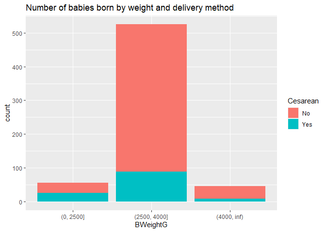

```r
FrenchBabes$Cesarean = as.factor(FrenchBabes$Cesarean)
ggplot(FrenchBabes, aes(x = BWeightG, fill = Cesarean)) +
  geom_bar(position = "stack") +
  scale_fill_discrete(name = "Cesarean", labels = c("No", "Yes")) +
  ggtitle("Number of babies born by weight and delivery method")
```

The majority of babies born are delivered without a cesarean section, and the majority of babies born weigh between 2500 and 4000 grams. It also appears that a cesarean section is most likely when babies weigh less than 2500 grams at birth.

### **(3)**

#### **Do a Chi-square test to see if the association between baby’s weight group and cesarean is significant if we use $\alpha=0.05$. Show the observed table and the expected table. What is the degrees of freedom? What is the p-value?**

```r
chi = chisq.test(FrenchBabes$BWeightG, FrenchBabes$Cesarean)
chi
```

```
##
##  Pearson's Chi-squared test
##
## data:  FrenchBabes$BWeightG and FrenchBabes$Cesarean
## X-squared = 24.893, df = 2, p-value = 3.931e-06
```

```r
chi$observed
```

```
##                     FrenchBabes$Cesarean
## FrenchBabes$BWeightG   0   1
##         (0, 2500]     31  25
##         (2500, 4000] 436  89
##         (4000, inf)   38   8
```

```r
chi$expected
```

```
##                     FrenchBabes$Cesarean
## FrenchBabes$BWeightG         0          1
##         (0, 2500]     45.10367  10.896332
##         (2500, 4000] 422.84689 102.153110
##         (4000, inf)   37.04944   8.950558
```

The association between baby’s weight and cesarean is significant with $\alpha=0.05$. The degrees of freedom is df = 2.  
The p-value is 3.931e-06.

## **Question 3 (10 points):**

#### **Please refer to “diet_data” which was posted on Blackboard. We want to see if consuming wine and weight-based exercise would affect the means of weight changes. Before the analysis, be sure to delete the rows with missing value in column “change”.**

Preprocessing

```r
diet_data = read.csv("C:/Users/jerem/Downloads/diet_data.csv")
diet = diet_data[!is.na(diet_data$change),] # [row, columns]
```

### **(1)**

#### **Plot a box plot with points representing the means to show the distribution of (1) weight changes (change) of consuming wine (wine) without weight-based exercise (weight), (2) consuming wine with weight-based exercise, (3) not consuming wine without weight-based exercise and (4) not consuming wine with weight-based exercise. Briefly describe what you find in the box plot.**

```r
summary(diet)
```

```
##      Date               Stone           Pounds           Ounces        weight_oz       calories     cals_per_oz
##  Length:140         Min.   :11.00   Min.   : 0.000   Min.   :0.000   Min.   :2628   Min.   :1400   Min.   :0.5100
##  Class :character   1st Qu.:11.00   1st Qu.: 1.000   1st Qu.:0.000   1st Qu.:2670   1st Qu.:2188   1st Qu.:0.8075
##  Mode  :character   Median :12.00   Median : 3.000   Median :4.000   Median :2689   Median :2575   Median :0.9550
##                     Mean   :11.54   Mean   : 6.157   Mean   :3.586   Mean   :2688   Mean   :3181   Mean   :1.1836
##                     3rd Qu.:12.00   3rd Qu.:12.000   3rd Qu.:6.000   3rd Qu.:2704   3rd Qu.:3850   3rd Qu.:1.4500
##                     Max.   :12.00   Max.   :13.000   Max.   :8.000   Max.   :2768   Max.   :9150   Max.   :3.4500
##   five_donuts          walk             run            wine             prot            weight           change
##  Min.   :0.0000   Min.   :0.0000   Min.   :0.00   Min.   :0.0000   Min.   :0.0000   Min.   :0.0000   Min.   :-58.000
##  1st Qu.:0.0000   1st Qu.:0.0000   1st Qu.:0.00   1st Qu.:0.0000   1st Qu.:0.0000   1st Qu.:0.0000   1st Qu.:-18.000
##  Median :0.0000   Median :1.0000   Median :0.00   Median :0.0000   Median :0.0000   Median :0.0000   Median : -3.000
##  Mean   :0.3714   Mean   :0.6786   Mean   :0.25   Mean   :0.3071   Mean   :0.1786   Mean   :0.4429   Mean   : -1.486
##  3rd Qu.:1.0000   3rd Qu.:1.0000   3rd Qu.:0.25   3rd Qu.:1.0000   3rd Qu.:0.0000   3rd Qu.:1.0000   3rd Qu.: 16.000
##  Max.   :1.0000   Max.   :1.0000   Max.   :1.00   Max.   :1.0000   Max.   :1.0000   Max.   :1.0000   Max.   :102.000
```

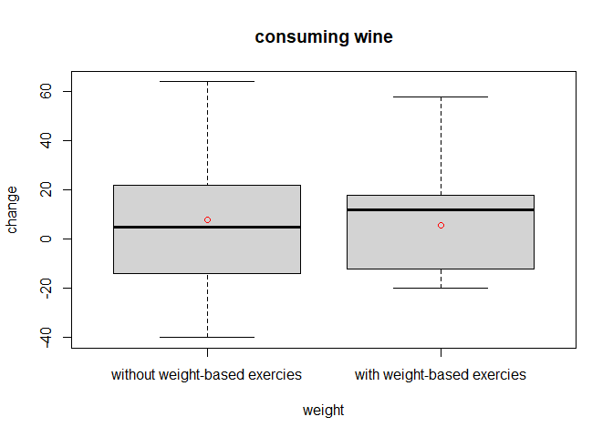

```r
wine_yes = filter(diet, diet$wine==1)
wine_no = filter(diet, diet$wine==0)

wine_yes_weight_yes = filter(wine_yes, wine_yes$weight==1)
wine_yes_weight_no = filter(wine_yes, wine_yes$weight==0)
wine_no_weight_yes = filter(wine_no, wine_no$weight==1)
wine_no_weight_no = filter(wine_no, wine_no$weight==0)

{
boxplot(data=wine_yes,
        change ~ weight,
        main="consuming wine",
        names= c("without weight-based exercies", "with weight-based exercies"))
points(c(mean(wine_yes_weight_yes$change), mean(wine_yes_weight_no$change)), col="red")
}
```

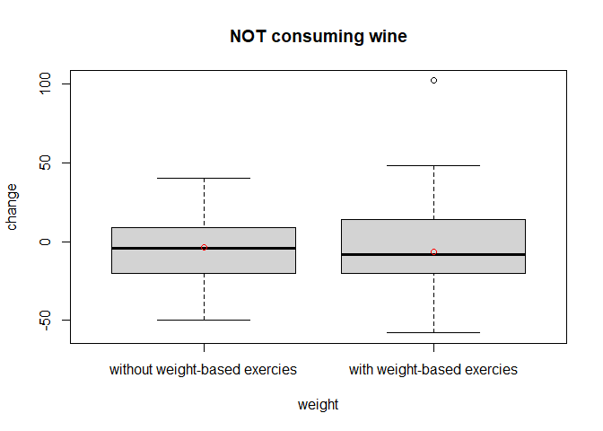

```r
{
boxplot(data=wine_no,
        change ~ weight,
        main="NOT consuming wine",
        names= c("without weight-based exercies", "with weight-based exercies"))
points(c(mean(wine_no_weight_yes$change), mean(wine_no_weight_no$change)), col="red")
}
```

### **(2)**

#### **Do a two-way ANOVA (analysis of variance) to see if weight-based exercise and consuming wine affect the means of weight changes. What conclusions can you make from the ANOVA test results and why?**

```r
aov2 = aov(change ~ weight * wine, data=diet)
aov2
```

```
## Call:
##    aov(formula = change ~ weight * wine, data = diet)
##
## Terms:
##                   weight     wine weight:wine Residuals
## Sum of Squares    126.54  4170.94        7.11  83258.38
## Deg. of Freedom        1        1           1       136
##
## Residual standard error: 24.74255
## Estimated effects may be unbalanced
```

```r
summary(aov2)
```

```
##              Df Sum Sq Mean Sq F value Pr(>F)
## weight        1    127     127   0.207 0.6501
## wine          1   4171    4171   6.813 0.0101 *
## weight:wine   1      7       7   0.012 0.9143
## Residuals   136  83258     612
## ---
## Signif. codes:  0 '***' 0.001 '**' 0.01 '*' 0.05 '.' 0.1 ' ' 1
```

**Interpreting 2 way anova in r:**  
There was not a statistically significant interaction between the effects of weight-based exercies and wine on weight change. Wine consuption is significant with a p-value of 0.01.

## **Question 4 (20 points):**

#### **Please refer to “diet_data” (HW2_diet_data.csv) which was posted on Blackboard.**

### **(1)**

#### **Do a linear regression using Excel and R to see if calories consuming per ounce daily would be able to predict daily weight changes. You will get a couple of tables in the results. Explain what the ANOVA table tells you. And explain what the coefficient table tells you. What are the confidence intervals of intercept $\beta_0$ and the slope $\beta_1$ if we set up the confidence level to be 95%? What is the value of R squared and what does the R squared tell you?**

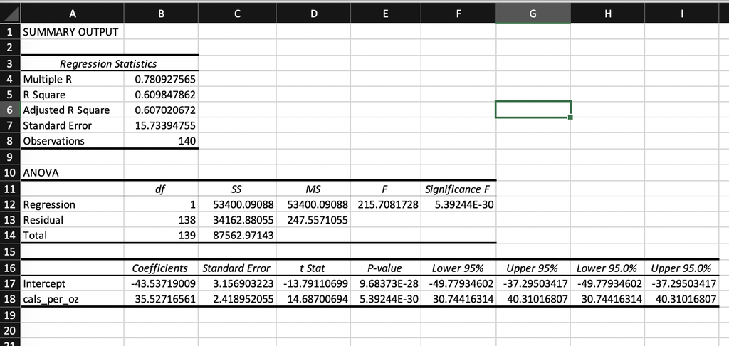

Excel Tables

```r
diet_fit = lm(data=diet, change ~ cals_per_oz)
summary(diet_fit)
```

```
##
## Call:
## lm(formula = change ~ cals_per_oz, data = diet)
##
## Residuals:
##     Min      1Q  Median      3Q     Max
## -39.687 -12.108   1.089  10.016  44.694
##
## Coefficients:
##             Estimate Std. Error t value Pr(>|t|)
## (Intercept)  -43.537      3.157  -13.79   <2e-16 ***
## cals_per_oz   35.527      2.419   14.69   <2e-16 ***
## ---
## Signif. codes:  0 '***' 0.001 '**' 0.01 '*' 0.05 '.' 0.1 ' ' 1
##
## Residual standard error: 15.73 on 138 degrees of freedom
## Multiple R-squared:  0.6098, Adjusted R-squared:  0.607
## F-statistic: 215.7 on 1 and 138 DF,  p-value: < 2.2e-16
```

**Annova table explanation:**  
There is a statistically significant difference among the population means. The p-value for 215.71 is 5.39E-30, so the test statistic is significat at that level.  
**Coefficient table explanation:**  
For each unit increase in calorie consumed per ounce daily, daily weight change increases with 35.52716561 units.  
**Conficdence intervals of intercept $\beta_0$ and slope $\beta_1$ if we set up the confidence level to be 95%:**

```r
confint(diet_fit, level=0.95)
```

```
##                 2.5 %    97.5 %
## (Intercept) -49.77935 -37.29503
## cals_per_oz  30.74416  40.31017
```

$\beta_0$ = -49.77935 & -37.29503  
$\beta_1$ = 30.74416 & 40.31017  
**R squared value and explanation:**  
$R^2$ value is 0.609847862. There is 61% variance in the dependent variable that the independent variables explain collectively.

### **(2)**

#### **Plot a scatter plot using R where x-axis is calories consuming per ounce and y-axis is weight changes. On the plot, add the regression line from (1). (hint: use function abline())**

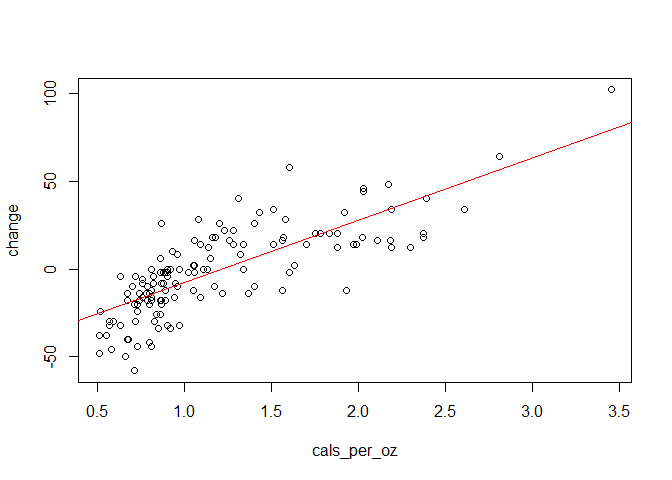

```r
plot(data=diet, change ~ cals_per_oz)
abline(diet_fit, col="red")
```

### **(3)**

#### **Check if your simple linear meets the assumptions regarding residuals using R. There are 4 assumptions for residuals.**

```r
cor.test(diet$change, diet_fit$residuals)
```

```
##
##  Pearson's product-moment correlation
##
## data:  diet$change and diet_fit$residuals
## t = 9.3961, df = 138, p-value < 2.2e-16
## alternative hypothesis: true correlation is not equal to 0
## 95 percent confidence interval:
##  0.5117492 0.7162973
## sample estimates:
##       cor
## 0.6246216
```

```r
mean(diet_fit$residuals)
```

```
## [1] 1.641442e-15
```

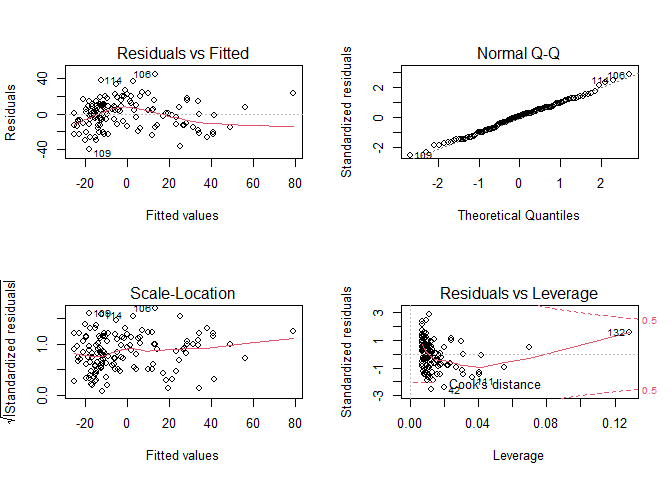

```r
par(mfrow = c(2,2))
plot(diet_fit)
```

### **(4)**

#### **Do a multivariate linear regression using R to see if calories consuming per ounce daily, main meal was bag of five jam donuts, walk, and one large glass of wine would be able to predict daily weight changes. Compare this model with the one you get from Part (1).**

```r
diet_mltpl_fit = lm(data=diet, change ~ cals_per_oz + five_donuts + walk + wine)
summary(diet_mltpl_fit)
```

```
##
## Call:
## lm(formula = change ~ cals_per_oz + five_donuts + walk + wine,
##     data = diet)
##
## Residuals:
##     Min      1Q  Median      3Q     Max
## -42.572 -11.226   0.109   9.949  46.607
##
## Coefficients:
##             Estimate Std. Error t value Pr(>|t|)
## (Intercept) -39.7242     4.8835  -8.134 2.39e-13 ***
## cals_per_oz  34.2203     2.8202  12.134  < 2e-16 ***
## five_donuts  -0.8740     2.9314  -0.298    0.766
## walk         -2.9434     3.2507  -0.905    0.367
## wine          0.1819     3.0412   0.060    0.952
## ---
## Signif. codes:  0 '***' 0.001 '**' 0.01 '*' 0.05 '.' 0.1 ' ' 1
##
## Residual standard error: 15.85 on 135 degrees of freedom
## Multiple R-squared:  0.6129, Adjusted R-squared:  0.6014
## F-statistic: 53.44 on 4 and 135 DF,  p-value: < 2.2e-16
```

```r
summary (diet_fit)
```

```
##
## Call:
## lm(formula = change ~ cals_per_oz, data = diet)
##
## Residuals:
##     Min      1Q  Median      3Q     Max
## -39.687 -12.108   1.089  10.016  44.694
##
## Coefficients:
##             Estimate Std. Error t value Pr(>|t|)
## (Intercept)  -43.537      3.157  -13.79   <2e-16 ***
## cals_per_oz   35.527      2.419   14.69   <2e-16 ***
## ---
## Signif. codes:  0 '***' 0.001 '**' 0.01 '*' 0.05 '.' 0.1 ' ' 1
##
## Residual standard error: 15.73 on 138 degrees of freedom
## Multiple R-squared:  0.6098, Adjusted R-squared:  0.607
## F-statistic: 215.7 on 1 and 138 DF,  p-value: < 2.2e-16
```

```r
anova(diet_fit, diet_mltpl_fit)
```

```
## Analysis of Variance Table
##
## Model 1: change ~ cals_per_oz
## Model 2: change ~ cals_per_oz + five_donuts + walk + wine
##   Res.Df   RSS Df Sum of Sq      F Pr(>F)
## 1    138 34163
## 2    135 33896  3       267 0.3545  0.786
```

**Explanation:**  
Calories per ounce consumed daily still shows the most statistically significant between both models.

## **Question 5 (40 points):**

#### **Please refer to heart failure data set (HW2_heart_failure_dataset.csv) that consists of 299 samples with 13 features.**

### **(1)**

#### **Load in the data using read.csv(). Do hierarchical clustering with complete linkage and Euclidean distance.**

```r
library(NbClust)
library(factoextra)
library(gridExtra)
hf_data = read.csv("HW2_heart_failure_dataset.csv")
hf_data = na.omit(hf_data)
sd_hf_data = scale(hf_data)
data.dist = dist(sd_hf_data, method = "euclidean")
comp_link = hclust(data.dist, method = "complete")
```

### **(2)**

#### **Plot the dendrogram and cut the dendrogram at a height that results in three distinct clusters.**

```r
hf_clust = cutree(comp_link, 3)
head(sort(comp_link$height, decreasing = TRUE))
```

```
## [1] 12.362414 10.669779 10.262642  9.537266  8.271275  7.999057
```

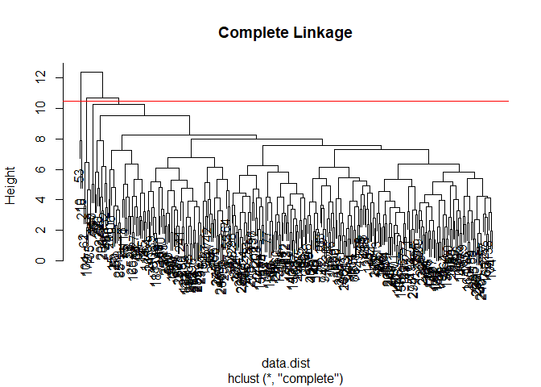

```r
plot(comp_link, main = "Complete Linkage")
abline(h = 10.5, col = 'red') # h is a value between the 2nd and 3rd split
```

### **(3)**

#### **Perform K-means clustering of the observations with $K = 3$. How well do the clusters that you obtained in K-means clustering compare to the true class labels?**

```r
km = kmeans(sd_hf_data, 3, nstart = 20)
table(km$cluster,hf_clust)
```

```
##    hf_clust
##       1   2   3
##   1  65   3   0
##   2 135   0   0
##   3  90   3   3
```

```r
table(hf_clust)
```

```
## hf_clust
##   1   2   3
## 290   6   3
```

```r
table(km$cluster)
```

```
##
##   1   2   3
##  68 135  96
```

### **(4)**

#### **Perform K-means clustering with $K = 2$ and $K=4$. Describe your results. How many clusters would you recommend based on elbow method?**

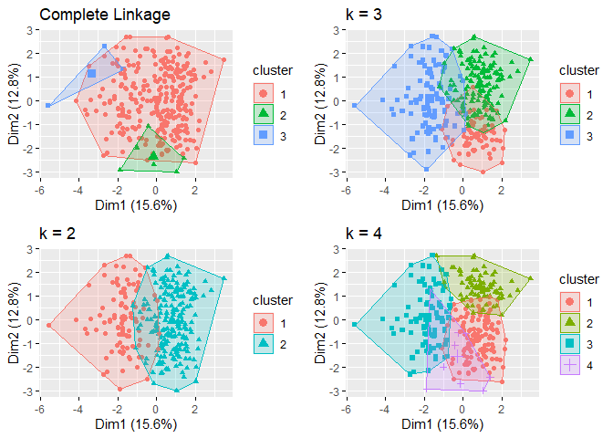

```r
km_2 = kmeans(sd_hf_data, 2, nstart = 20)
km_4 = kmeans(sd_hf_data, 4, nstart = 20)
plot1 = fviz_cluster(list(data = sd_hf_data, cluster = hf_clust), geom = "point") + ggtitle ("Complete Linkage")
plot2 = fviz_cluster(km, geom = "point", data = sd_hf_data) + ggtitle ("k = 3")
plot3 = fviz_cluster(km_2, geom = "point", data = sd_hf_data) + ggtitle ("k = 2")
plot4 = fviz_cluster(km_4, geom = "point", data = sd_hf_data) + ggtitle ("k = 4")
grid.arrange(plot1,plot2,plot3,plot4, nrow =2)
```

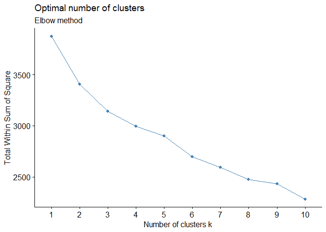

```r
fviz_nbclust(sd_hf_data, kmeans, method = "wss") + labs(subtitle = "Elbow method")
```

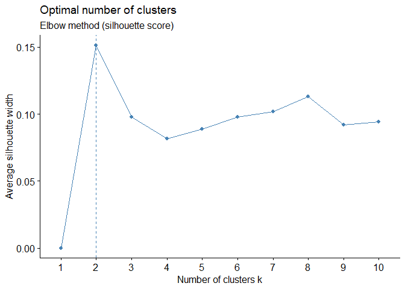

```r
fviz_nbclust(sd_hf_data, kmeans, method = "silhouette") + labs(subtitle = "Elbow method (silhouette score)")
```

Based on the cluster graphs and the two elbow methods, 2 clusters should be recommended.